# Data Analysis with R - Lesson 3

### Reading in Data

```r
pf <- read.csv('pseudo_facebook.tsv', sep = '\t')
names(pf)
```

```
##  [1] "userid"                "age"
##  [3] "dob_day"               "dob_year"
##  [5] "dob_month"             "gender"
##  [7] "tenure"                "friend_count"
##  [9] "friendships_initiated" "likes"
## [11] "likes_received"        "mobile_likes"
## [13] "mobile_likes_received" "www_likes"
## [15] "www_likes_received"
```

### Histogram of Users’ Birthdays

We will first create a histogram. What is a histogram?

*Histograms are useful data summaries that convey the following information:*

- The general shape of the frequency distribution (normal, chi-square, etc.)
- Symmetry of the distribution and whether it is skewed - Modality: unimodal, bimodal, or multimodal
- The histogram of the frequency distribution can be converted to a probability distribution by dividing the tally in each group by the total number of data points to give the relative frequency.

The shape of the distribution conveys important information such as the probability distribution of the data. In cases in which the distribution is known, a histogram that does not fit the distribution may provide clues about a process and measurement problem. For example, a histogram that shows a higher than normal frequency in bins near one end and then a sharp drop-off may indicate that the observer is “helping” the results by classifying extreme data in the less extreme group.  
[[Source](http://www.netmba.com/statistics/histogram/)]

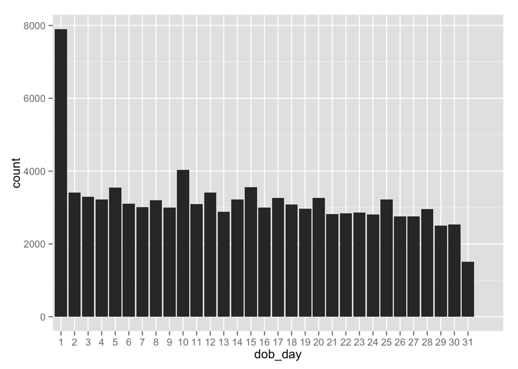

```r
library(ggplot2)
qplot(x = dob_day, data = pf) + scale_x_discrete(breaks = 1:31)
```

```r
#equivalent ggplot
#ggplot(aes(x = dob_day), data = pf) + geom_histogram() + scale_x_discrete(breaks = 1:31)
```

#### What are some things that you notice about this histogram?

Most birthdays on first day of the month - likely due to the user keeping the default option.

### Moira’s Investigation

Facebook engineer investigated people’s perception of how many people saw their post

#### Think about a time when you posted a specific message or shared a photo on Facebook. What was it?

Response: Infograph

#### How many of your friends do you think saw that post?

Response: 50

#### Think about what percent of your friends on Facebook see any posts or comments that you make in a month. What percent do you think that is?

Response: 30%

### Faceting

Notes:

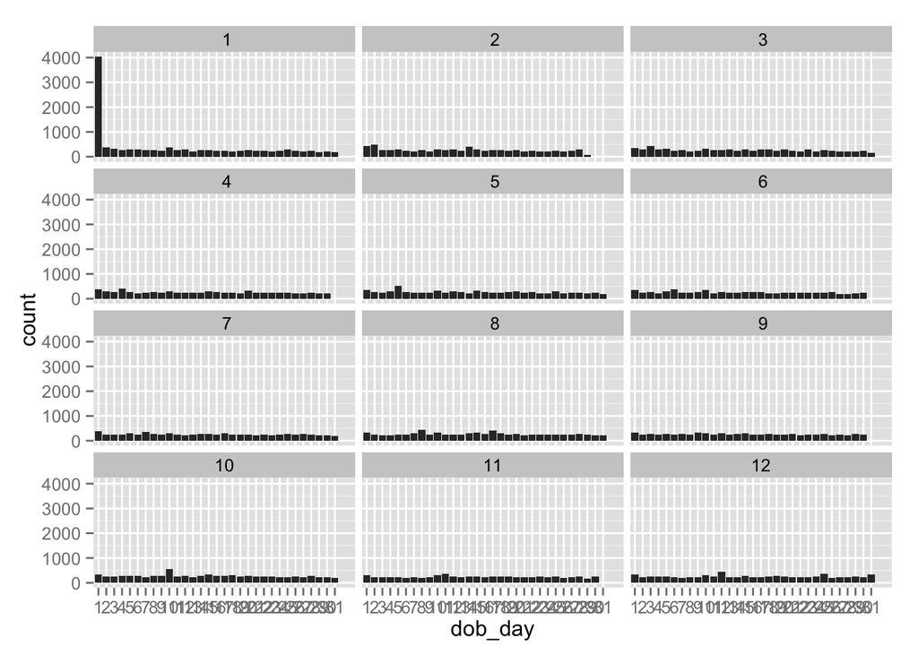

```r
qplot(x = dob_day, data=pf) + scale_x_discrete(breaks=1:31) + facet_wrap(~dob_month, ncol=3)
```

```r
#equivalent ggplot
# ggplot(data=pf, aes(x=dob_bday)) + geom_histogram() + scale_x_discrete(breaks=1:31) + facet_wrap(~dob_month)
```

### Be Skeptical - Outliers and Anomalies

#### Moira’s Outlier

Notes: The average audience size was higher than expected. Upon digging into the response, there was an outlier where a user entered their estimated audience size to be over 10 million friends.

#### Which case do you think applies to Moira’s outlier?

Response: Bad data with a false extreme value (a user entered 10 million friends)

### Friend Count

#### What code would you enter to create a histogram of friend counts?

```
## stat_bin: binwidth defaulted to range/30. Use 'binwidth = x' to adjust this.
```

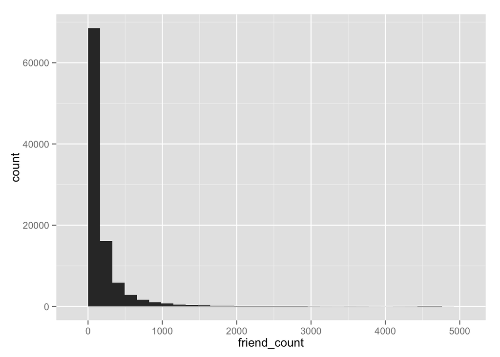

```r
qplot(x = friend_count, data = pf) #with long tail
```

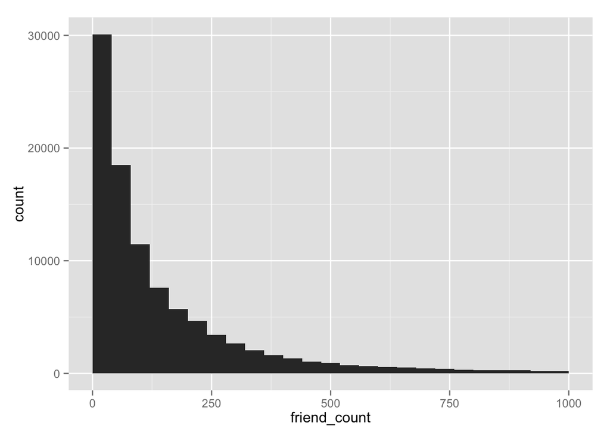

```r
qplot(x = friend_count, data = pf, binwidth=40, xlim = c(0, 1000))
```

```r
#ggplot(aes(x = friend_count), data = pf) + geom_histogram()
```

#### Limiting the Axes

Notes:

```
## stat_bin: binwidth defaulted to range/30. Use 'binwidth = x' to adjust this.
```

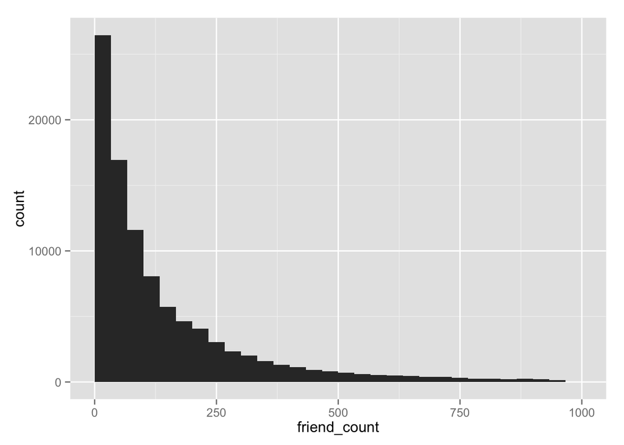

```r
qplot(x = friend_count, data = pf, xlim = c(0, 1000))
```

```r
#ggplot(aes(x = friend_count), data = pf) + geom_histogram() + scale_x_continuous(limits = c(0, 1000))
```

### Exploring with Bin Width

#### Adjusting the Bin Width

Notes:

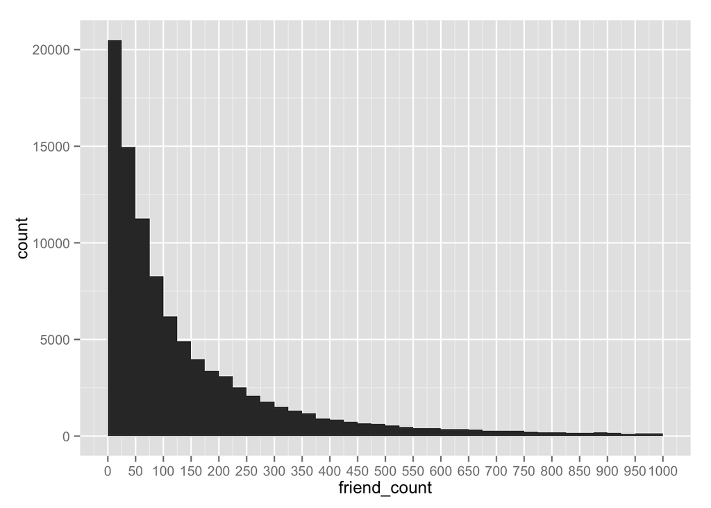

```r
qplot(x = friend_count, data = pf, binwidth = 25) + scale_x_continuous(limits = c(0, 1000), breaks = seq(0, 1000, 50))
```

```r
#seq(start, end, interval)
```

#### Faceting Friend Count

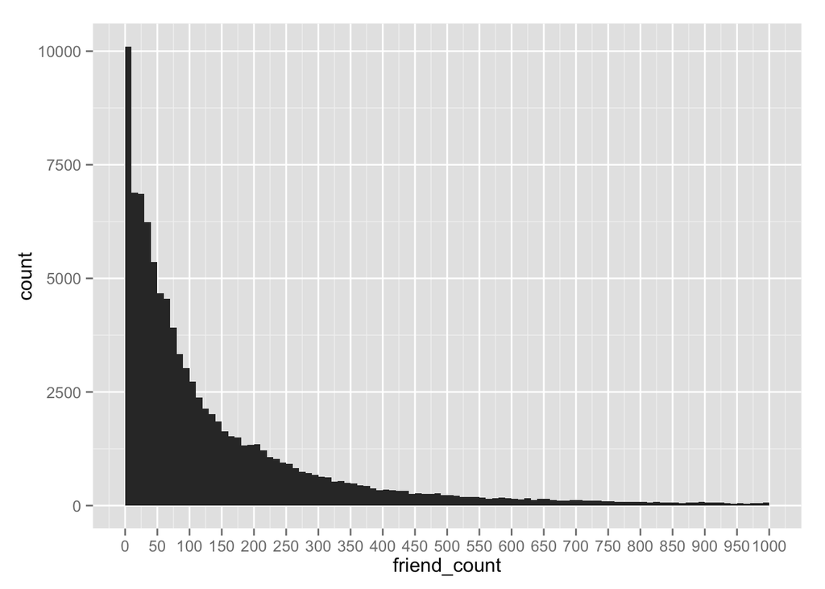

```r
# What code would you add to create a facet the histogram by gender?
# Add it to the code below.
qplot(x = friend_count, data = pf, binwidth = 10) +
  scale_x_continuous(limits = c(0, 1000),
                     breaks = seq(0, 1000, 50))
```

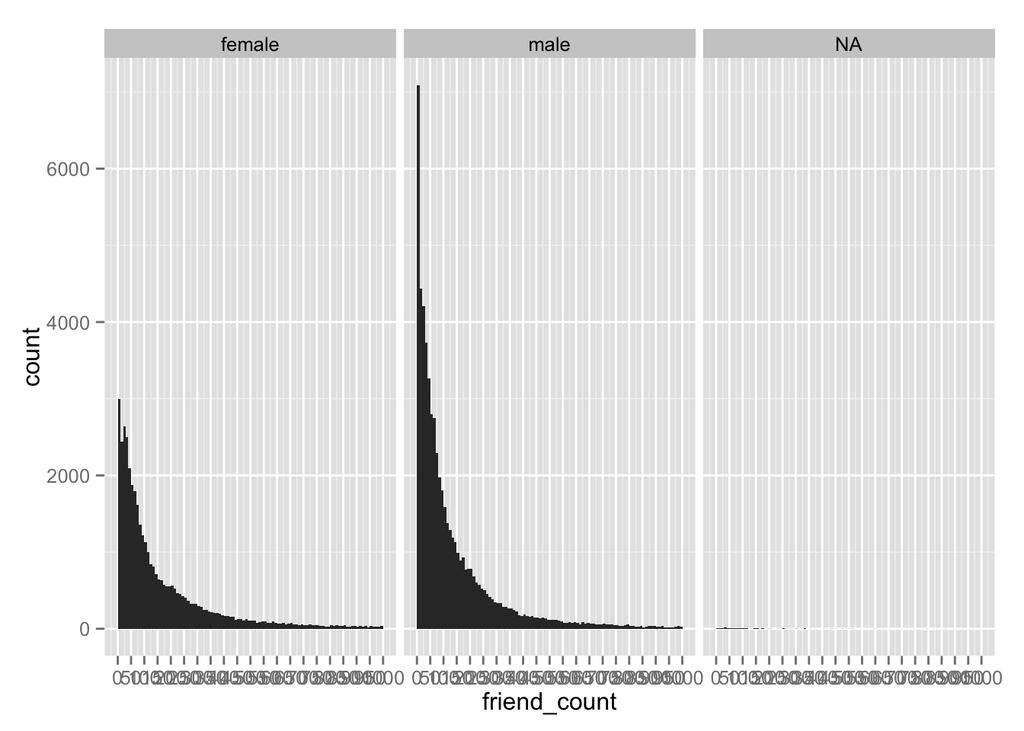

```r
qplot(x = friend_count, data = pf, binwidth = 10) + scale_x_continuous(limits = c(0, 1000), breaks = seq(0, 1000, 50)) + facet_wrap(~gender)
```

### Omitting NA Values

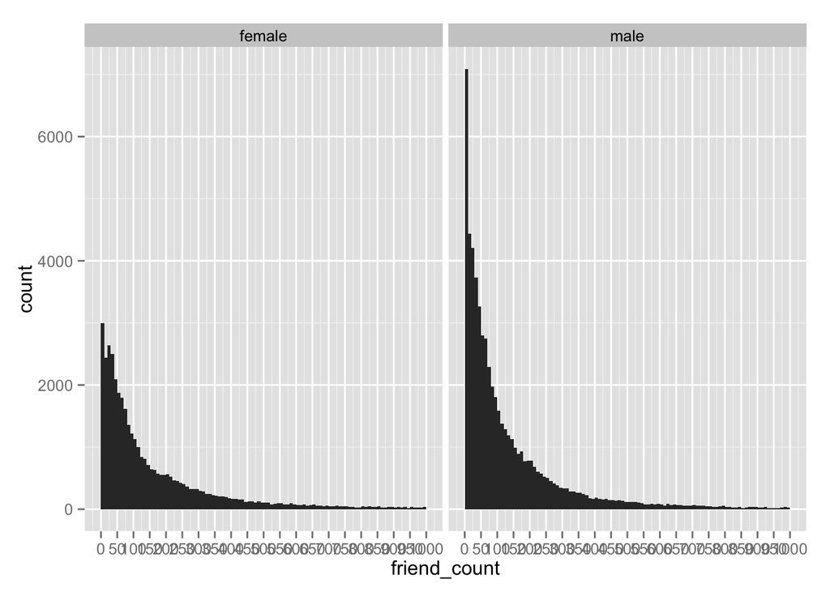

```r
qplot(x = friend_count, data = subset(pf, !is.na(gender)), binwidth = 10) + scale_x_continuous(limits = c(0, 1000), breaks = seq(0, 1000, 50)) + facet_wrap(~gender)
```

```r
#ggplot(aes(x = friend_count), data = subset(pf, !is.na(gender))) + geom_histogram() + scale_x_continuous(limits = c(0, 1000), breaks = seq(0, 1000, 50)) + facet_wrap(~gender)
```

### Statistics ‘by’ Gender

Notes:

```r
table(pf$gender)
```

```
##
## female   male
##  40254  58574
```

```r
by(pf$friend_count, pf$gender, summary)
```

```
## pf$gender: female
##    Min. 1st Qu.  Median    Mean 3rd Qu.    Max.
##       0      37      96     242     244    4923
## --------------------------------------------------------
## pf$gender: male
##    Min. 1st Qu.  Median    Mean 3rd Qu.    Max.
##       0      27      74     165     182    4917
```

#### Who on average has more friends: men or women?

Response: Women

#### What’s the difference between the median friend count for women and men?

Response: 22

#### Why would the median be a better measure than the mean?

Response: Median is more robust (halfway point), a few people with high number of friends influence the mean.

### Tenure

Notes:

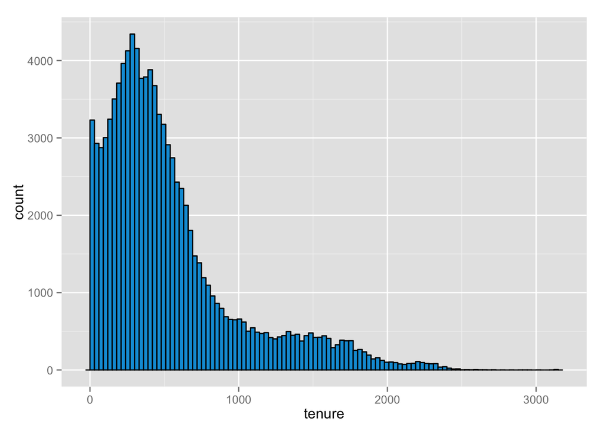

```r
qplot(x = tenure, data = pf, binwidth = 30, color = I('black'), fill = I('#099DD9'))
```

```r
#ggplot(aes(x = tenure), data = pf) + geom_histogram(binwidth = 30, color = 'black', fill = '#099DD9')
```

#### Create a histogram of tenure by year?

```r
summary(pf$tenure)
```

```
##    Min. 1st Qu.  Median    Mean 3rd Qu.    Max.    NA's
##     0.0   226.0   412.0   537.9   675.0  3139.0       2
```

```
## stat_bin: binwidth defaulted to range/30. Use 'binwidth = x' to adjust this.
```

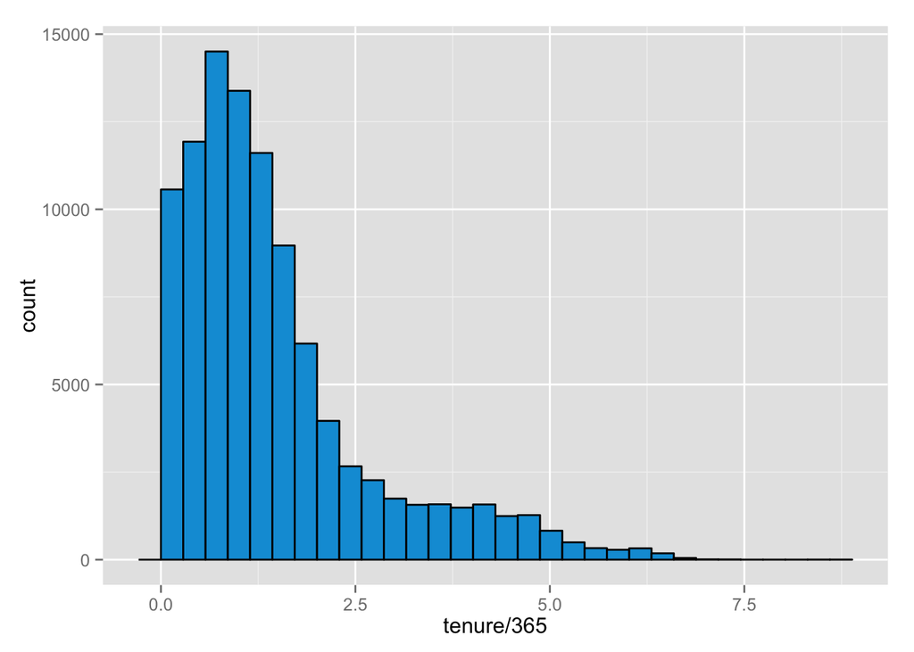

```r
qplot(x = tenure/365, data = pf, color = I('black'), fill = I('#099DD9'))
```

```r
#ggplot(aes(x = tenure/365), binwidth = 0.25, data = pf) + geom_histogram(binwidth = .25, color = 'black', fill = '#F79420')
```

### Labeling Plots

```
## stat_bin: binwidth defaulted to range/30. Use 'binwidth = x' to adjust this.
```

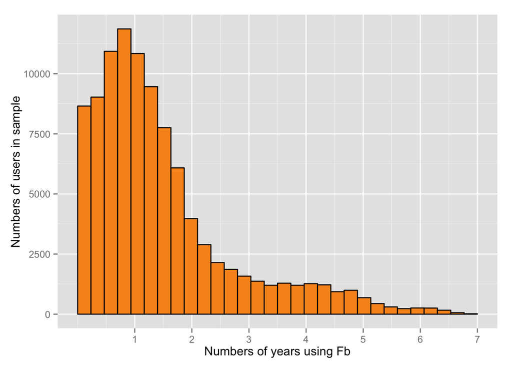

```r
qplot(x=tenure/365, data=pf, xlab='Numbers of years using Fb', ylab='Numbers of users in sample', color = I('black'), fill = I('#F79420')) + scale_x_continuous(breaks = seq(1, 7, 1), lim = c(0,7))
```

```r
#ggplot(aes(x = tenure / 365), data = pf) + geom_histogram(color = 'black', fill = '#F79420') + scale_x_continuous(breaks = seq(1, 7, 1), limits = c(0, 7)) + xlab('Number of years using Facebook') + ylab('Number of users in sample')
```

### User Ages

Notes:

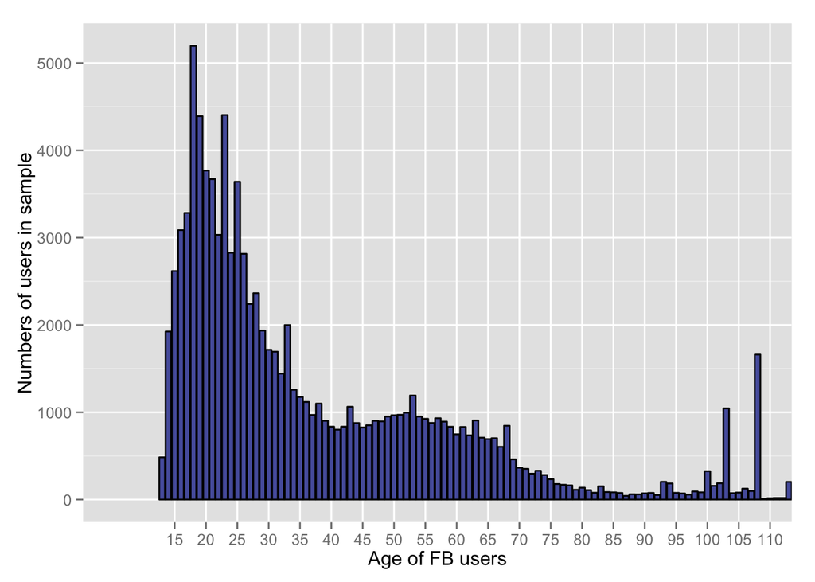

```r
#find max age
#summary(pf)
#bin width = 1 because of age
qplot(x=age, binwidth = 1, data=pf, xlab='Age of FB users', ylab='Numbers of users in sample', color = I('black'), fill = I('#5760AB')) + scale_x_discrete(breaks=seq(0,113,5))
```

#### What do you notice?

Most users under 30 years.

### Transforming Data

```r
#install.packages('gridExtra')
library(gridExtra)
```

```
## stat_bin: binwidth defaulted to range/30. Use 'binwidth = x' to adjust this.
## stat_bin: binwidth defaulted to range/30. Use 'binwidth = x' to adjust this.
## stat_bin: binwidth defaulted to range/30. Use 'binwidth = x' to adjust this.
```

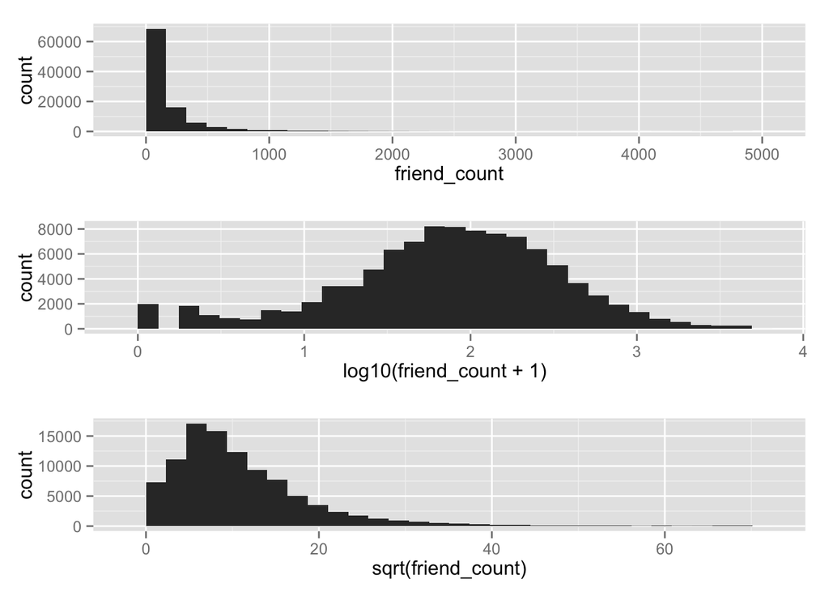

```r
#define individual plots
p1 = qplot(x = friend_count, data = pf)
# added 1 to avoid infinity value as log10(0) is undefined.
p2 = qplot(x = log10(friend_count + 1), data=pf)
p3 = qplot(x= sqrt(friend_count), data = pf)
# arrange plots in grid
grid.arrange(p1, p2, p3, ncol=1)
```

```r
#Alternate solution
#p1 <- ggplot(aes(x = friend_count), data=pf) + geom_histogram()
#p2 <- p1 + scale_x_log10()
#p3 <- p1 + scale_x_sqrt()
#grid.arrange(p1,p2, p3, ncol=1)
```

### Add a Scaling Layer

Notes:

```
## stat_bin: binwidth defaulted to range/30. Use 'binwidth = x' to adjust this.
## stat_bin: binwidth defaulted to range/30. Use 'binwidth = x' to adjust this.
```

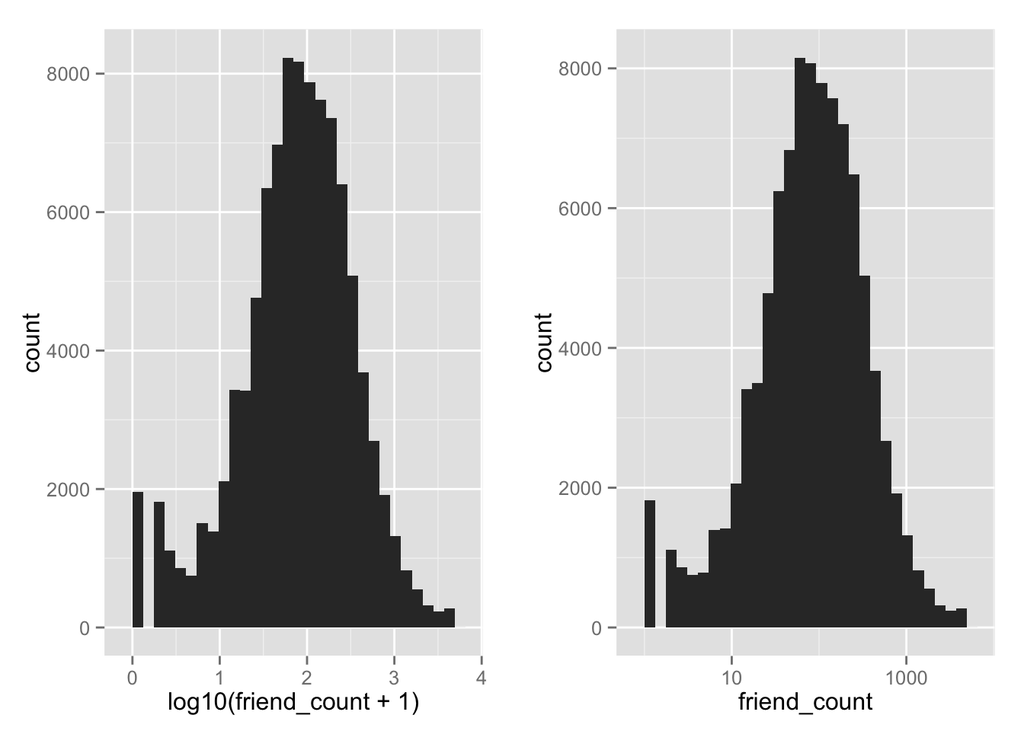

```r
#x-axis in log unit
logScale <- qplot(x=log10(friend_count + 1), data=pf)
countScale <- ggplot(aes(x=friend_count), data=pf) + geom_histogram() + scale_x_log10()
grid.arrange(logScale, countScale, ncol=2)
```

### Frequency Polygons

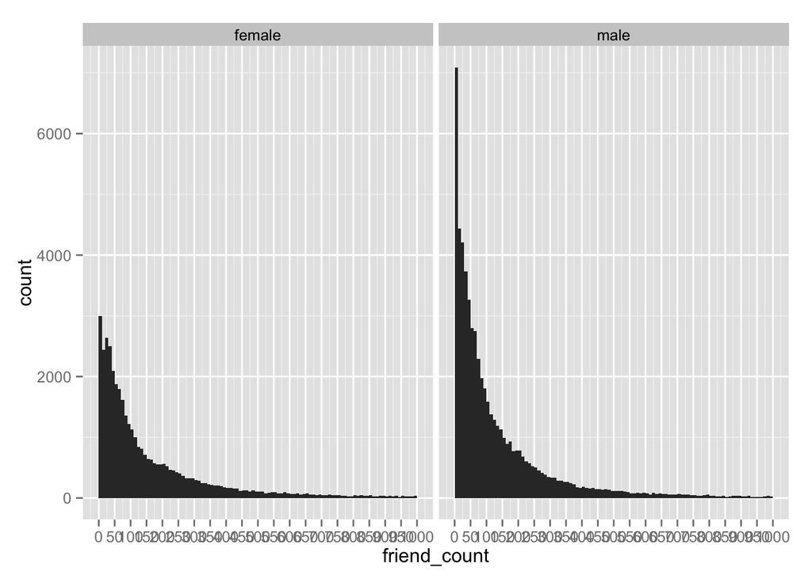

```r
#Earlier gender friend count distribution
qplot(x=friend_count, data=subset(pf, !is.na(gender)),binwidth=10) + scale_x_continuous(lim = c(0,1000), breaks = seq(0,1000, 50)) + facet_wrap(~gender)
```

```
## stat_bin: binwidth defaulted to range/30. Use 'binwidth = x' to adjust this.
```

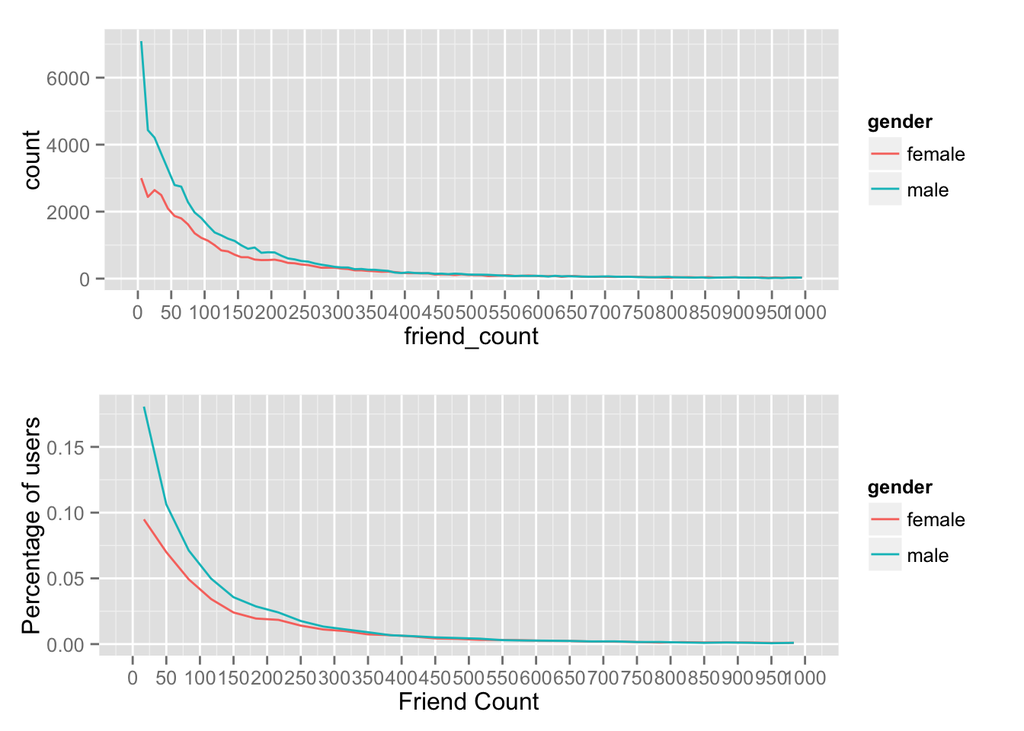

```r
p1 = qplot(x=friend_count, data=subset(pf, !is.na(gender)),binwidth=10, geom = 'freqpoly', color = gender) + scale_x_continuous(lim = c(0,1000), breaks = seq(0,1000, 50))
#p2 = qplot(x=friend_count, y= ..count../sum(..count..), data=subset(pf, !is.na(gender)),binwidth=10, geom = 'freqpoly', color = gender) + scale_x_continuous(lim = c(0,1000), breaks = seq(0,1000, 50))

#ggplot version
p2 = ggplot(aes(x = friend_count, y = ..count../sum(..count..)), data = subset(pf, !is.na(gender))) + geom_freqpoly(aes(color = gender)) + scale_x_continuous(limits = c(0, 1000), breaks = seq(0, 1000, 50)) + xlab('Friend Count') + ylab('Percentage of users')

grid.arrange(p1, p2, ncol=1)
```

### Likes on the Web

```r
#Let's take a look at the labels again
#names(pf)
summary(pf$www_likes_received)
```

```
##      Min.   1st Qu.    Median      Mean   3rd Qu.      Max.
##      0.00      0.00      2.00     58.57     20.00 130000.00
```

```
## stat_bin: binwidth defaulted to range/30. Use 'binwidth = x' to adjust this.
```

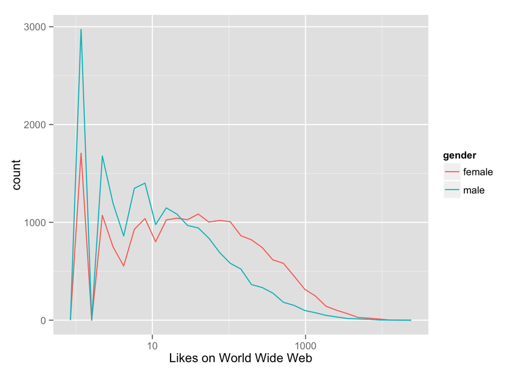

```r
#Notice the log scale as it's a long tail distribution
qplot(x=www_likes, xlab='Likes on World Wide Web', ylab='count', data=subset(pf, !is.na(gender)), geom = 'freqpoly', color = gender) + scale_x_log10()
```

```
## stat_bin: binwidth defaulted to range/30. Use 'binwidth = x' to adjust this.
```

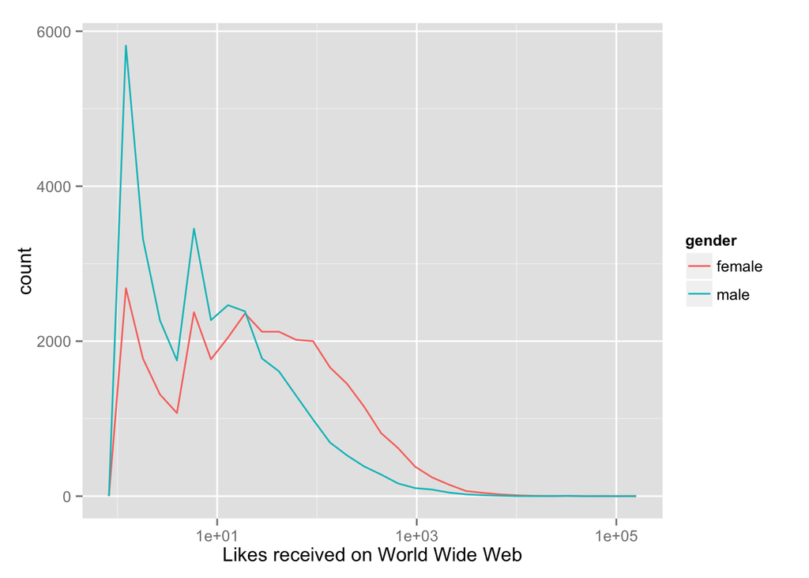

```r
#likes received
qplot(x=www_likes_received, xlab='Likes received on World Wide Web', ylab='count', data=subset(pf, !is.na(gender)), geom = 'freqpoly', color = gender) + scale_x_log10()
```

```r
#by(v1, split_variable, total so use sum function)
#Shows females have more likes
by(pf$www_likes, pf$gender, sum)
```

```
## pf$gender: female
## [1] 3507665
## --------------------------------------------------------
## pf$gender: male
## [1] 1430175
```

### Box Plots

Notes:

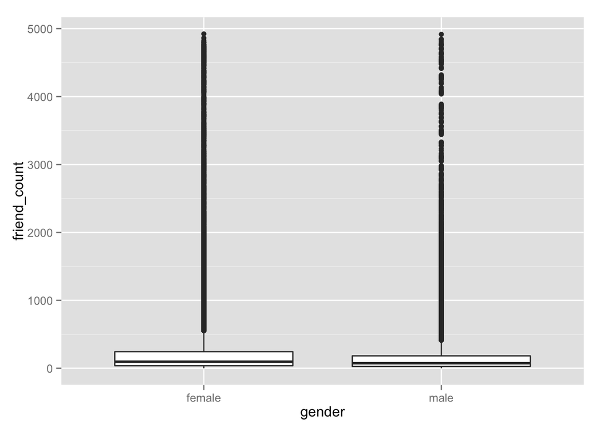

```r
qplot(x=gender, y=friend_count, data=subset(pf, !is.na(gender)), geom= 'boxplot')
```

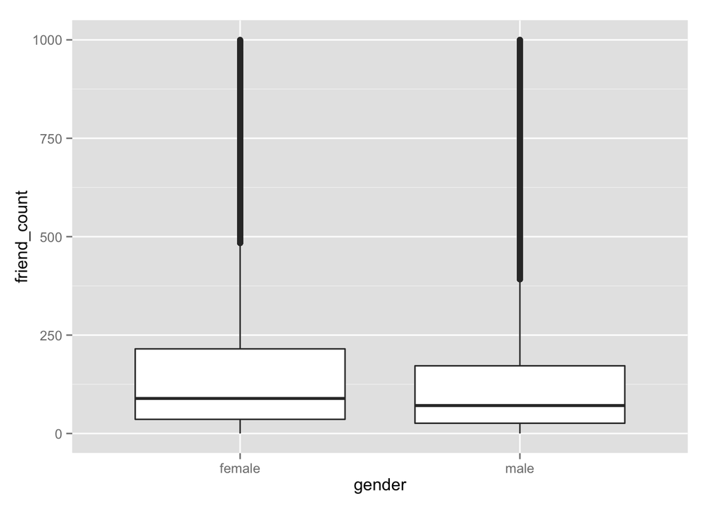

```r
#limit y axes
qplot(x=gender, y=friend_count, data=subset(pf, !is.na(gender)), geom= 'boxplot',  ylim = c(0,1000))
```

```r
# another option
#qplot(x=gender, y=friend_count, data=subset(pf, !is.na(gender)), geom= 'boxplot') + scale_y_continuous(limits = c(0, 1000))
```

#### Adjust the code to focus on users who have friend counts between 0 and 1000.

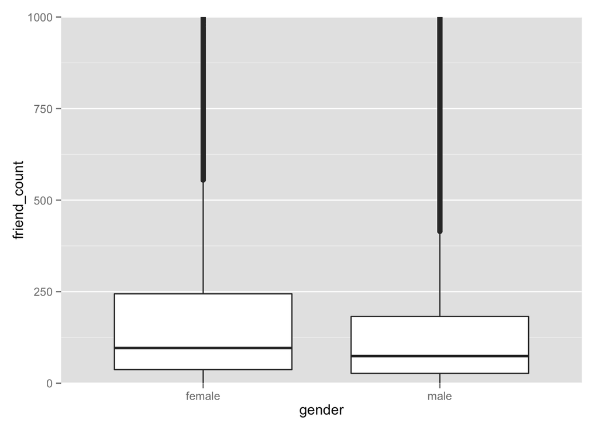

```r
# coord cartesian layer
qplot(x=gender, y=friend_count, data=subset(pf, !is.na(gender)), geom= 'boxplot') + coord_cartesian(ylim = c(0,1000))
```

### Box Plots, Quartiles, and Friendships

Notes:

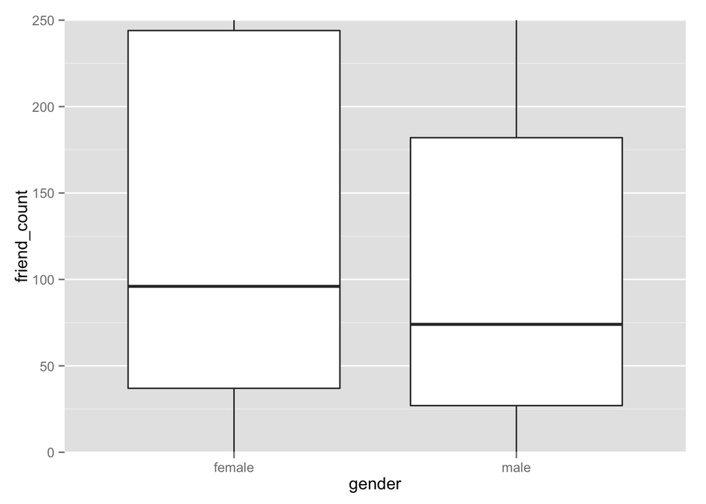

```r
qplot(x=gender, y=friend_count, data = subset(pf, !is.na(gender)), geom = 'boxplot') + coord_cartesian(ylim=c(0,250))
```

```r
#interpret box plot - compare the values w/ the boxplot graph
by(pf$friend_count, pf$gender, summary)
```

```
## pf$gender: female
##    Min. 1st Qu.  Median    Mean 3rd Qu.    Max.
##       0      37      96     242     244    4923
## --------------------------------------------------------
## pf$gender: male
##    Min. 1st Qu.  Median    Mean 3rd Qu.    Max.
##       0      27      74     165     182    4917
```

#### On average, who initiated more friendships in our sample: men or women?

```r
names(pf)
```

```
##  [1] "userid"                "age"
##  [3] "dob_day"               "dob_year"
##  [5] "dob_month"             "gender"
##  [7] "tenure"                "friend_count"
##  [9] "friendships_initiated" "likes"
## [11] "likes_received"        "mobile_likes"
## [13] "mobile_likes_received" "www_likes"
## [15] "www_likes_received"
```

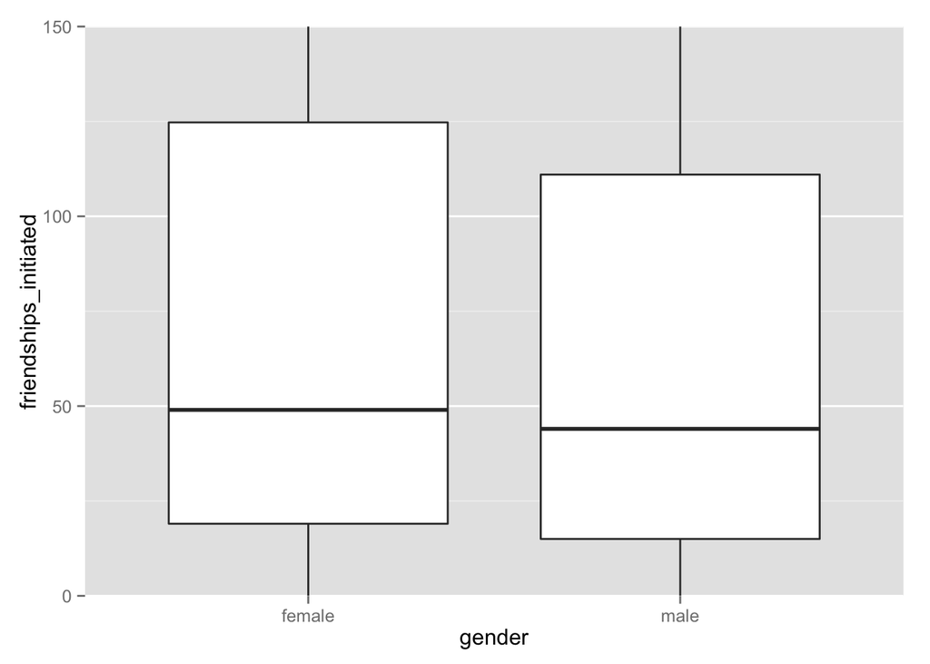

```r
qplot(x=gender, y=friendships_initiated, data = subset(pf, !is.na(gender)), geom = 'boxplot') + coord_cartesian(ylim=c(0,150))
```

```r
#using by() to compare with boxplot
by(pf$friendships_initiated, pf$gender, summary)
```

```
## pf$gender: female
##    Min. 1st Qu.  Median    Mean 3rd Qu.    Max.
##     0.0    19.0    49.0   113.9   124.8  3654.0
## --------------------------------------------------------
## pf$gender: male
##    Min. 1st Qu.  Median    Mean 3rd Qu.    Max.
##     0.0    15.0    44.0   103.1   111.0  4144.0
```

```r
#sum
by(pf$friendships_initiated, pf$gender, sum)
```

```
## pf$gender: female
## [1] 4584894
## --------------------------------------------------------
## pf$gender: male
## [1] 6037023
```

Response: On average, female users initiate more friendshipsby a slight margin.

### Should we focus our resources on mobile development?

Notes:

```r
summary(pf$mobile_likes)
```

```
##    Min. 1st Qu.  Median    Mean 3rd Qu.    Max.
##     0.0     0.0     4.0   106.1    46.0 25110.0
```

```r
summary(pf$mobile_likes > 0)
```

```
##    Mode   FALSE    TRUE    NA's
## logical   35056   63947       0
```

```r
pf$mobile_check_in <- NA
pf$mobile_check_in <- ifelse(pf$mobile_likes > 0, 1, 0)
#summary(pf$mobile_check_in)
sum(pf$mobile_check_in ==1)/(length(pf$mobile_check_in))
```

```
## [1] 0.6459097
```

Response: Around 64% of our pseudo-facebook users check in through their mobile devices therefore, we need to commit a higher percentage of our resources to develop a great mobile experience.

If you have time, don’t forget to take this course for free at Udacity. Can’t beat the price!